# **Modelos de regresión**

- Mostrar todo el código
- Ocultar todo el código
- Ver el código fuente

Fecha de publicación

2 de octubre de 2026

# Objetivo del manual

- Comprender la inferencia estadística a través de los modelos de regresión lineal
- Familiarizarse con la construcción de modelos lineales
- Extender los modelos lineales a diferentes estructuras de datos

Paquetes a utilizar en este manual:

**Código**

```r
# instalar/cargar paquetes

sketchy::load_packages(
  c("ggplot2",
    "viridis",
    "lmerTest",
    "sjPlot")
  )
```

Regresión lineal simple

Las regresiones lineales se basan en la ecuación lineal *a = mx + b* que aprendimos en el colegio. La representación formal tiene este aspecto:

$\hat{Y} \sim \beta_{o} + \beta_{1} * x_{1}$

- $\hat{Y}$: variable respuesta
- $\beta_{o}$: intercepto
- $\beta_{1}$: estimado de la magnitud del efecto de $x_{1}$ en $\hat{Y}$ (también conocido como tamaño de efecto, coeficiente o simplemente “estimado”)
- $x_{1}$: variable predictora

El objetivo más común de una regresión lineal es la estimación de los valores de $\beta_{*}$. Esto se consigue encontrando la línea recta que mejor se ajusta y que representa la asociación entre un predictor y la respuesta:

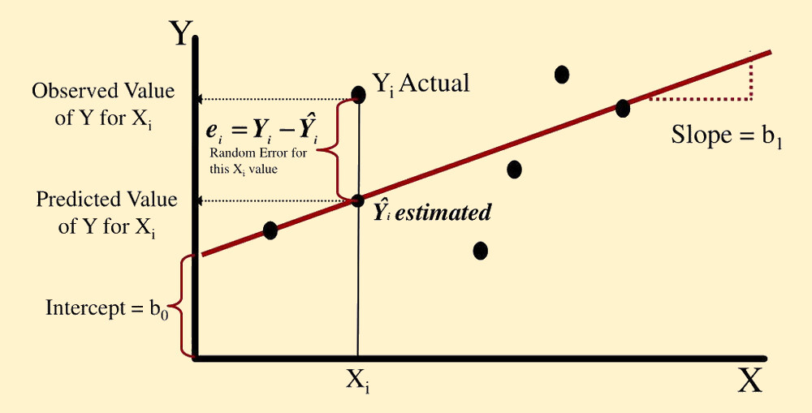

Estos $\beta_{*}$ son el tamaño de efecto estimado del predictor correspondiente (por ejemplo, $\beta_{1}$ es el tamaño de efecto $x_{1}$). Su valor representa el cambio medio en $\hat{Y}$ (en unidades $\hat{Y}$) para una unidad de cambio en $\beta_{*}$. Por lo tanto, la hipótesis nula es que esos $\beta_{*}$ no son diferentes de 0:

$\qquad \mathcal{H}_0: \hat{Y} = \beta_0 + 0 * x_{1}$

lo que equivale a esto:

$\qquad \mathcal{H}_0: \hat{Y} = \beta_0$

Por ejemplo, un modelo de regresión con este resultado:

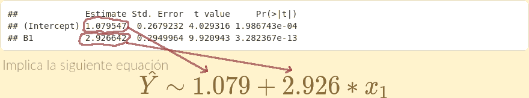

# 1 Regresión lineal en R

Para sacar el máximo provecho de los modelos lineales necesitamos sentirnos cómodos con ellos. Empezaremos explorando la función de regresión lineal de R `lm()`. En R la mayoría de los modelos lineales y sus extensiones comparten formatos comunes de entrada de datos y resultados, lo que facilita su aplicación una vez que entendemos sus fundamentos.

Utilizaremos el juego de datos ‘trees’ que viene por defecto con R. ‘trees’ proporciona medidas del **diámetro** (etiquetado como ‘Girth’), **altura** y **volumen** de 31 cerezos talados:

**Código**

```r
head(trees)
```

| Girth | Height | Volume |
| --- | --- | --- |
| 8.3 | 70 | 10.3 |
| 8.6 | 65 | 10.3 |
| 8.8 | 63 | 10.2 |
| 10.5 | 72 | 16.4 |
| 10.7 | 81 | 18.8 |
| 10.8 | 83 | 19.7 |

La función básica de R para construir un modelo lineal es `lm()`. Veamos los componentes básicos de un modelo de regresión utilizando `lm()`:

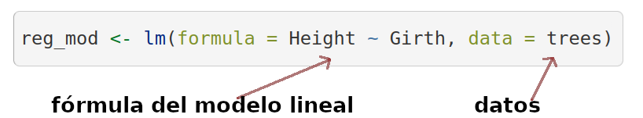

Podemos correr este modelo para ver el resultado:

**Código**

```r
reg_mod <- lm(formula = Height ~ Girth, data = trees)

summary(reg_mod)
```

```
Call:
lm(formula = Height ~ Girth, data = trees)

Residuals:
    Min      1Q  Median      3Q     Max
-12.582  -2.769   0.316   2.473   9.946

Coefficients:
            Estimate Std. Error t value Pr(>|t|)
(Intercept)   62.031      4.383   14.15  1.5e-14 ***
Girth          1.054      0.322    3.27   0.0028 **
---
Signif. codes:  0 '***' 0.001 '**' 0.01 '*' 0.05 '.' 0.1 ' ' 1

Residual standard error: 5.54 on 29 degrees of freedom
Multiple R-squared:  0.27,  Adjusted R-squared:  0.244
F-statistic: 10.7 on 1 and 29 DF,  p-value: 0.00276
```

Esto es lo que significan los elementos de la salida:

- **Llamada** (call): la función y los parámetros que se utilizaron para crear el modelo
- **Residuos** (residuals): distribución de los residuos. Los residuos son la diferencia entre lo que predijo el modelo y el valor real de *y*. Esta es una representación gráfica de los residuos:

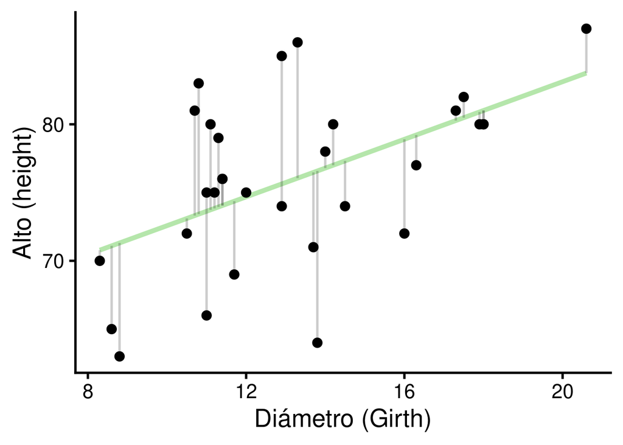

- **Coeficientes** (coefficients): contiene los tamaños de efecto (‘Estimates’), una medida de su incertidumbre (‘Standar error’), la estadística asociada (‘t value’) y el valor p (‘Pr(>|t|)’). Los tamaño de efecto o estimados se dan como el cambio promedio en *y* por cada aumento de 1 unidad en *x*. Para este ejemplo el estimado es de 1,0544 $in / in$. A pesar de que las unidades se anulan (`1,0544 $in / in$ = 1,0544) tenerlas en cuenta sigue siendo biológicamente significativo. Significan que, en promedio, y un aumento de 1 pulgada en la circunferencia que se espera un aumento de 1,0544 pulgadas en la altura.
- **Error estándar de los residuos** (residual standard error): se explica por sí mismo. El error estándar de los residuos
- **R-cuadrado múltiple** (multiple R-squared): el coeficiente de determinación, que pretende ser una medida de lo bien que su modelo se ajusta a los datos
- **R-cuadrado ajustado** (adjusted R-squared): similar al ‘R-cuadrado múltiple’ pero penalizado por el número de parámetros
- **Estadístico F** (F-statistic): estadístico para una prueba global que comprueba si al menos uno de sus coeficientes es distinto de cero
- **Valor de p**: probabilidad de una prueba global que comprueba si al menos uno de sus coeficientes es distinto de cero

Utilizaremos `lm()` para mostrar la flexibilidad de los modelos de regresión. Los componentes de regresión se añadirán gradualmente para que podamos tomarnos el tiempo de entender cada uno de ellos así como los correspondientes cambios en la salida de la regresión.

## 1.1 Modelo solo con intercepto

Primero vamos a crear una variable numérica de respuesta:

**Código**

```r
# definir semilla
set.seed(123)

# numero de observaciones
n <- 50

#  variables aleatorias
y <- rnorm(n = n, mean = 0, sd = 1)

# put it in a data frame
y_data <- data.frame(y)
```

Esta única variable puede introducirse en un **modelo de regresión sólo con intercepto**. Para ello, debemos suministrar la fórmula del modelo y los datos a `lm()`:

**Código**

```r
# run model
y_mod <- lm(formula = y ~ 1, data = y_data)
```

Lo que equivale a:

$\hat{Y} \sim \beta_{o}$

Podemos obtener el resumen por defecto de los resultados del modelo ejecutando `summary()` en el objeto de salida ‘y_mod’:

**Código**

```r
summary(y_mod)
```

```
Call:
lm(formula = y ~ 1, data = y_data)

Residuals:
   Min     1Q Median     3Q    Max
-2.001 -0.594 -0.107  0.664  2.135

Coefficients:
            Estimate Std. Error t value Pr(>|t|)
(Intercept)   0.0344     0.1309    0.26     0.79

Residual standard error: 0.926 on 49 degrees of freedom
```

Puede ser bastante informativo graficar los tamaños de efecto (aunque en este caso sólo tenemos uno):

**Código**

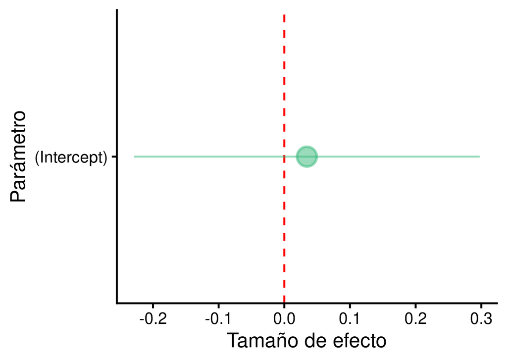

```r
ci_df <- data.frame(param = names(y_mod$coefficients),
                    est = y_mod$coefficients, confint(y_mod))

ggplot(ci_df, aes(x=param, y=est)) +
  geom_hline(yintercept = 0, color="red", lty = 2) +
  geom_pointrange(aes(ymin = X2.5.., ymax = X97.5..)) +
  labs(x = "Parámetro", y = "Tamaño de efecto") +
  coord_flip()
```

**Interpretación del modelo**

Para evaluar la importancia de la asociación nos centramos en la tabla de coeficientes:

```
            Estimate Std. Error t value Pr(>|t|)
(Intercept) 0.034404    0.13094 0.26275  0.79385
```

- En este ejemplo no hay predictores en el modelo, por lo que sólo tenemos una estimación para el intercepto ($\beta_0$)
- El modelo nos dice que el intercepto se estima en 0.0344 y que este valor no es significativamente diferente de 0 (valor p = 0.79385)
- En este caso el intercepto es simplemente la media de la variable de respuesta

**Código**

```r
mean(y_data$y)
```

```
[1] 0.034404
```

- Rara vez tenemos predicciones sobre el intercepto, por lo que tendemos a ignorar esta estimación.

**Caso de estudio**

- Ruhs, E. C., Martin, L. B., & Downs, C. J. (2020). [**The impacts of body mass on immune cell concentrations in birds**](https://royalsocietypublishing.org/doi/pdf/10.1098/rspb.2020.0655?download=true). *Proceedings of the Royal Society B*, 287(1934), 20200655.

“*Encontramos que un modelo sólo con intercepto (intercept-only model) explicaba mejor las concentraciones de linfocitos y eosinófilos en las aves, indicando que las concentraciones de estos tipos de células eran independientes de la masa corporal.*”

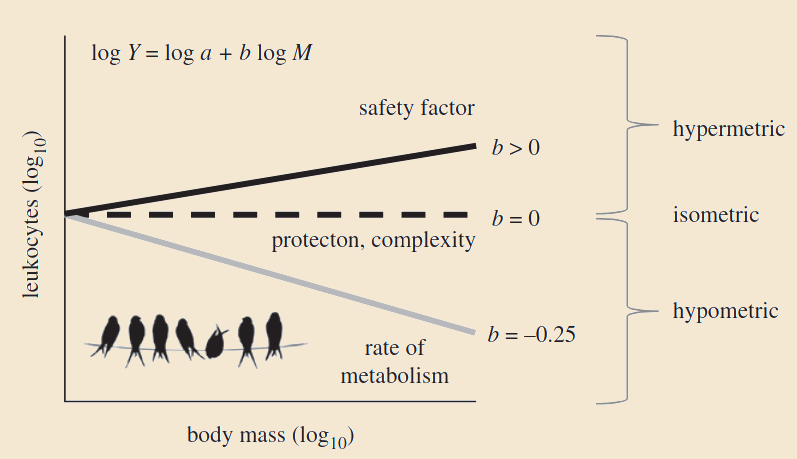

Ejercicio 3

- Cambie el argumento ‘mean’ en la llamada de la función “rnorm()` en la simulación para el modelo de solo intercepto un valor distinto de 0 y observe cómo cambian los valores en la tabla de coeficientes
- Cambia el argumento `sd` en la llamada a la función `rnorm()` por un valor más alto y observe cómo cambian los valores en la tabla de coeficientes

## 1.2 Añadir un predictor no asociado

Podemos crear 2 variables numéricas no relacionadas así:

**Código**

```r
# definir semilla
set.seed(123)

# numero de observaciones
n <- 50

#  variables aleatorias
y <-  rnorm(n = n, mean = 0, sd = 1)
x1 <-  rnorm(n = n, mean = 0, sd = 1)

# crear data frame
xy_datos <- data.frame(x1, y)
```

Estas dos variables pueden introducirse en un modelo de regresión para evaluar la asociación entre ellas:

**Código**

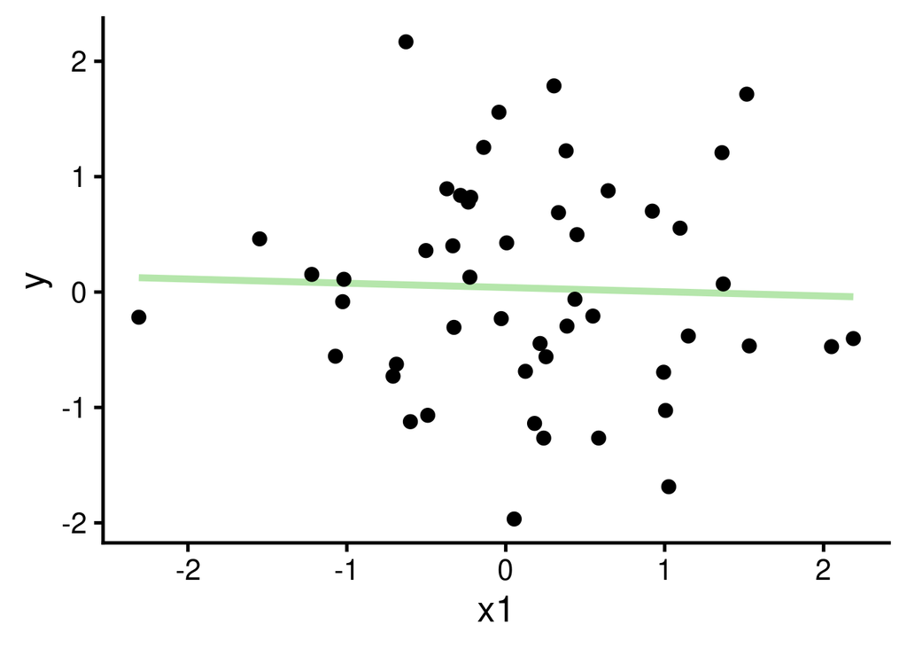

```r
# construir model
xy_mod <- lm(formula = y ~ x1, data = xy_datos)

# graficar
ggplot(xy_datos, aes(x = x1, y = y)) +
  geom_smooth(method = "lm", se = FALSE) +
  geom_point() # graficar points
```

Que es equivalente a esto:

$\hat{Y} \sim \beta_{o} + \beta_{1} * x_{1}$

Imprimamos el resumen de este modelo:

**Código**

```r
summary(xy_mod)
```

```
Call:
lm(formula = y ~ x1, data = xy_datos)

Residuals:
   Min     1Q Median     3Q    Max
-2.004 -0.624 -0.123  0.687  2.106

Coefficients:
            Estimate Std. Error t value Pr(>|t|)
(Intercept)   0.0398     0.1340    0.30     0.77
x1           -0.0367     0.1475   -0.25     0.80

Residual standard error: 0.935 on 48 degrees of freedom
Multiple R-squared:  0.00129,   Adjusted R-squared:  -0.0195
F-statistic: 0.0618 on 1 and 48 DF,  p-value: 0.805
```

… y graficar los tamaños de efecto:

**Código**

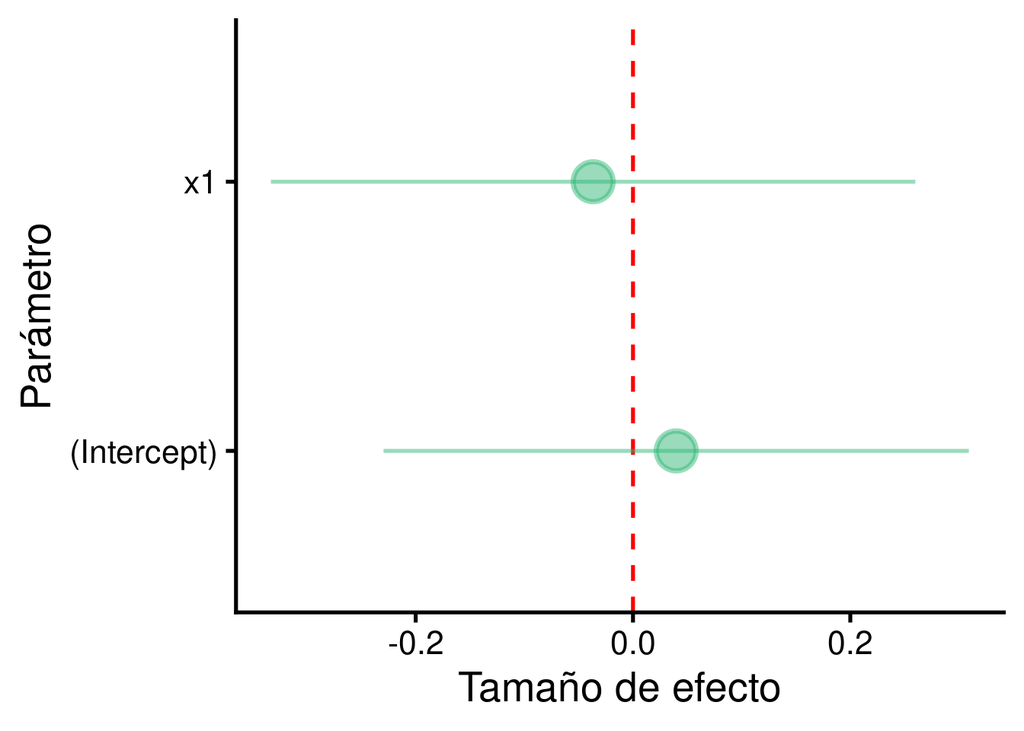

```r
ci_df <- data.frame(param = names(xy_mod$coefficients),
                    est = xy_mod$coefficients, confint(xy_mod))

ggplot(ci_df, aes(x=param, y=est)) +
  geom_hline(yintercept = 0, color="red", lty = 2) +
  geom_pointrange(aes(ymin = X2.5.., ymax = X97.5..)) +
  labs(x = "Parámetro", y = "Tamaño de efecto") +
  coord_flip()
```

Deberíamos “diagnosticar” la idoneidad del modelo inspeccionando más de cerca la distribución de los residuos. La función `plot_model()` del paquete `sjPlot` hace un buen trabajo para crear gráficos de diagnóstico para modelos lineales:

**Código**

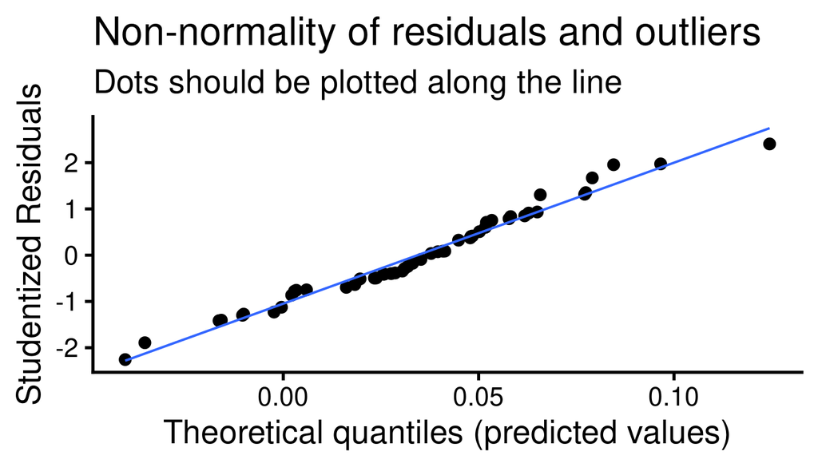

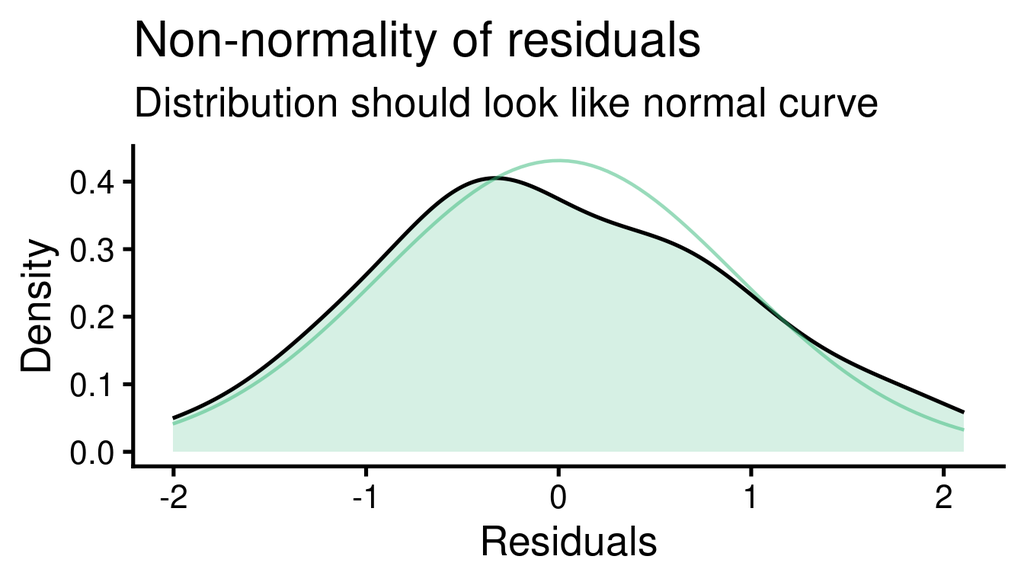

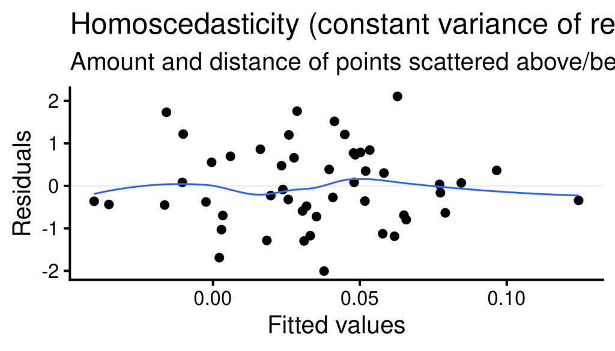

```r
plot_model(xy_mod, type = "diag")
```

**Interpretación del modelo**

Cuadro con coeficientes:

```
             Estimate Std. Error  t value Pr(>|t|)
(Intercept)  0.039774    0.13396  0.29690  0.76782
x1          -0.036679    0.14750 -0.24867  0.80467
```

- En este ejemplo hemos añadido un predictor al modelo, por lo que hemos obtenido una estimado adicional (y una fila extra, ‘x1’)
- El modelo nos dice que la estimación de ‘x1’ es -0.03668 y que no es significativamente diferente de 0 (p = 0.80467)

## 1.3 Simular un predictor asociado

Podemos utilizar la fórmula del modelo lineal anterior para simular dos variables continuas asociadas así:

**Código**

```r
# definir semilla
set.seed(123)

# numero de observaciones
n <- 50
b0 <- -4
b1 <- 3
error <- rnorm(n = n, sd = 3)

# variables aleatorias
x1 <-  rnorm(n = n, mean = 0, sd = 1)
y <- b0 + b1 * x1 + error

# crear data frame
xy_datos2 <- data.frame(x1, y)
```

Note que **también hemos añadido un término de error**, por lo que la asociación no es perfecta. Vamos a correr el modelo y graficar la asociación entre las dos variables:

**Código**

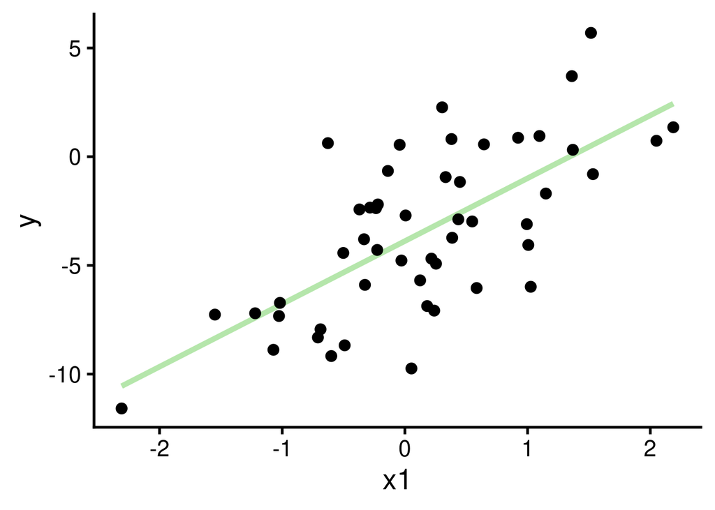

```r
# construir model
xy_mod2 <- lm(formula = y ~ x1, data = xy_datos2)

# graficar
ggplot(xy_datos2, aes(x = x1, y = y)) +
  geom_smooth(method = "lm", se = FALSE) +
  geom_point() # graficar points
```

La fórmula es la misma que la del modelo anterior:

$\hat{Y} \sim \beta_{o} + \beta_{1} * x_{1}$

Este es el resumen del modelo:

**Código**

```r
summary(xy_mod2)
```

```
Call:
lm(formula = y ~ x1, data = xy_datos2)

Residuals:
   Min     1Q Median     3Q    Max
 -6.01  -1.87  -0.37   2.06   6.32

Coefficients:
            Estimate Std. Error t value Pr(>|t|)
(Intercept)   -3.881      0.402   -9.66  7.9e-13 ***
x1             2.890      0.442    6.53  3.9e-08 ***
---
Signif. codes:  0 '***' 0.001 '**' 0.01 '*' 0.05 '.' 0.1 ' ' 1

Residual standard error: 2.8 on 48 degrees of freedom
Multiple R-squared:  0.471, Adjusted R-squared:  0.459
F-statistic: 42.7 on 1 and 48 DF,  p-value: 3.85e-08
```

.. el gráfico con los tamaños de efecto:

**Código**

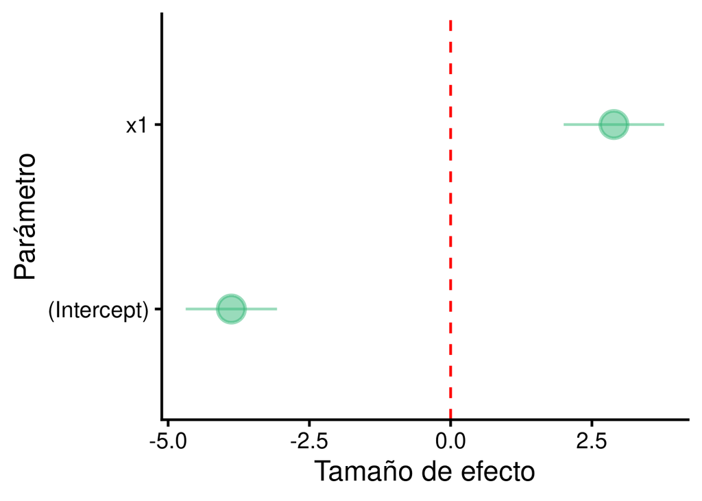

```r
ci_df <- data.frame(param = names(xy_mod2$coefficients),
                    est = xy_mod2$coefficients, confint(xy_mod2))

ggplot(ci_df, aes(x=param, y=est)) +
  geom_hline(yintercept = 0, color="red", lty = 2) +
  geom_pointrange(aes(ymin = X2.5.., ymax = X97.5..)) +
  labs(x = "Parámetro", y = "Tamaño de efecto") +
  coord_flip()
```

… y los gráficos diagnósticos del modelo:

**Código**

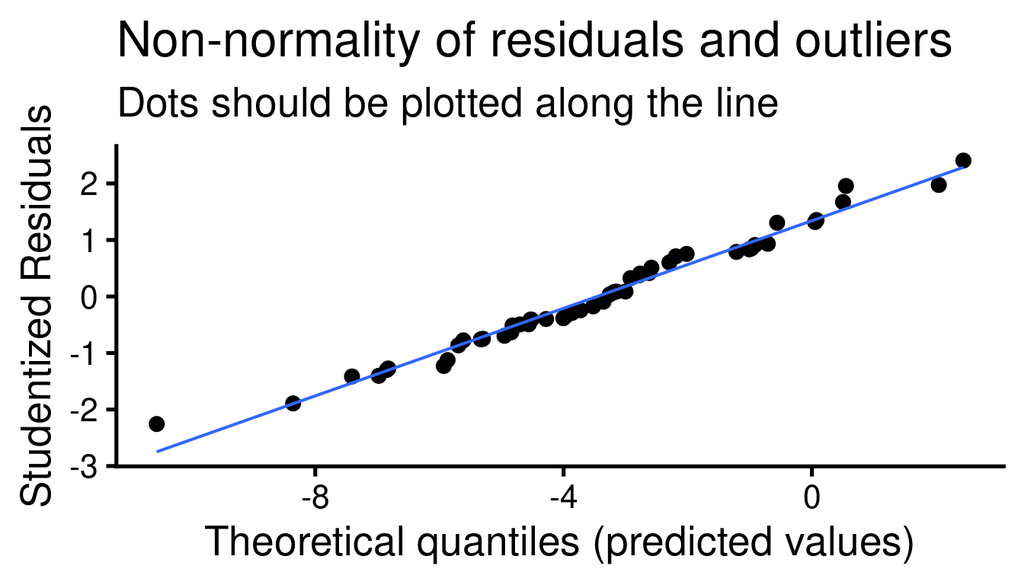

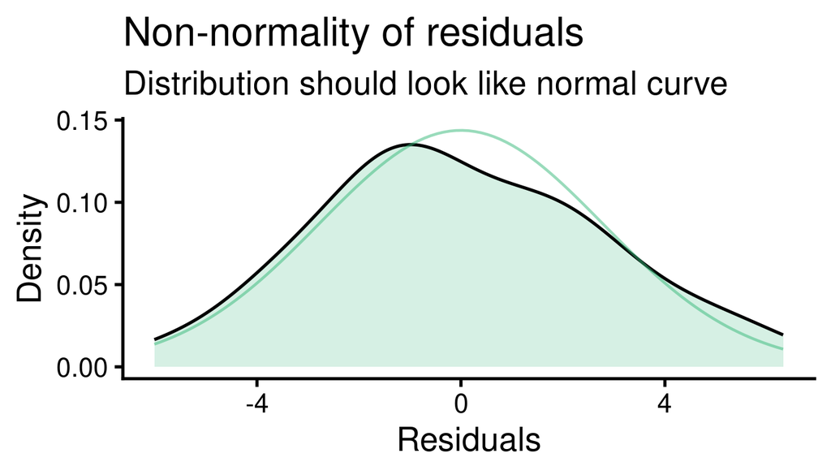

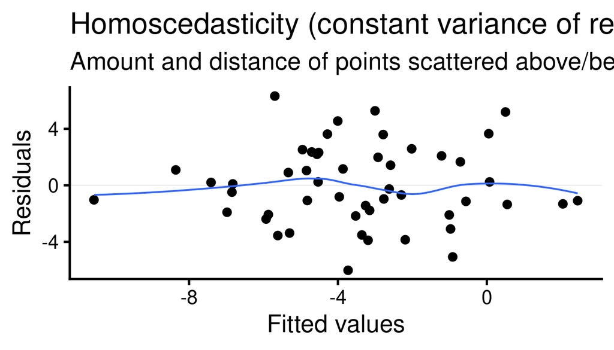

```r
plot_model(xy_mod2, type = "diag")
```

**Interpretación del modelo**

Cuadro con los coeficientes (estimados):

```
            Estimate Std. Error t value   Pr(>|t|)
(Intercept)  -3.8807    0.40188 -9.6562 7.8616e-13
x1            2.8900    0.44249  6.5311 3.8537e-08
```

- El modelo nos dice que $beta_1$ (el tamaño de efecto de ‘x1’) es 2.88996 y que es significativamente diferente de 0 (p = 3.85365^{-8})
- Los valores simulados de los parámetros de regresión pueden compararse con el resumen del modelo `lm()` para tener una idea de la precisión del modelo:
  - $\beta_1$ (the effect size of ‘x1’) was set to 3 and was estimated as 2.89 by the model

**Caso de estudio**

Wilkinson R, Pickett K, Cato MS. The spirit level. Why more equal societies almost always do better. 2009.

Index of: Life expectancy, Math & Literacy, Infant mortality, Homicides, Imprisonment, Teenage births, Trust, Obesity Mental illness, incl. drug & alcohol addiction, Social mobility

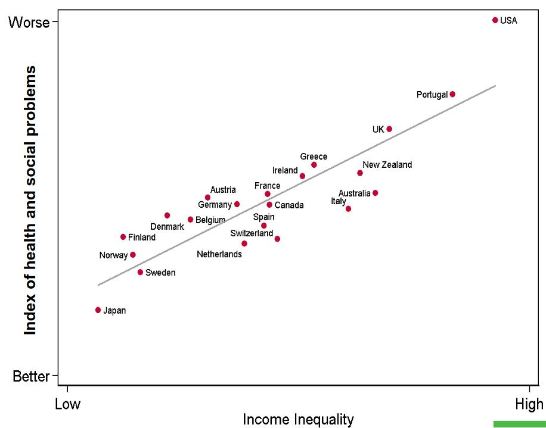

Ejercicio 4

- Aumente el tamaño de la muestra (`n`) a 1000 o más
- ¿Cómo cambiaron los estimados del tamaño de efecto ($\beta$)?
- ¿Cómo cambió los intervalos de confianza del tamaño de efecto?
- Ahora cambie `n` a 15 y compruebe de nuevo las estimaciones del modelo (esta vez compruebe también el valor p)

## 1.4 Varios predictores: regresión múltiple

La regresión lineal múltiple es una extensión del modelo de regresión lineal simple que puede tomar varios predictores:

$\hat{Y} \sim \beta_{o} + \beta_{1} * x_{1} + \cdots + \beta_{n} * x_{n}$

La fórmula parece compleja, pero sólo quiere decir que cualquier parámetro adicional tendrá su propia estimación ($\beta$). La fórmula para una regresión lineal de dos predictores se ve así:

$\hat{Y} \sim \beta_{o} + \beta_{1} * x_{1} + \beta_{2} * x_{2}$

… y se puede simular así:

**Código**

```r
# semila
set.seed(123)

# numero de observaciones
n <- 50
b0 <- -4
b1 <- 3
b2 <- -2
error <- rnorm(n = n, mean = 0, sd = 3)

# variables aleatorias
x1 <-  rnorm(n = n, mean = 0, sd = 1)
x2 <-  rnorm(n = n, mean = 0, sd = 1)
y <- b0 + b1 * x1 + b2 * x2 + error

# crear un data frame
xy_datos_multp <- data.frame(x1, x2, y)

# construir el modelo
xy_mod_multp <- lm(formula = y ~ x1 + x2, data = xy_datos_multp)

summary(xy_mod_multp)
```

```
Call:
lm(formula = y ~ x1 + x2, data = xy_datos_multp)

Residuals:
   Min     1Q Median     3Q    Max
-5.986 -1.893 -0.363  2.002  6.413

Coefficients:
            Estimate Std. Error t value Pr(>|t|)
(Intercept)   -3.865      0.417   -9.27  3.5e-12 ***
x1             2.901      0.453    6.41  6.4e-08 ***
x2            -1.932      0.414   -4.67  2.6e-05 ***
---
Signif. codes:  0 '***' 0.001 '**' 0.01 '*' 0.05 '.' 0.1 ' ' 1

Residual standard error: 2.83 on 47 degrees of freedom
Multiple R-squared:  0.612, Adjusted R-squared:  0.595
F-statistic:   37 on 2 and 47 DF,  p-value: 2.23e-10
```

… graficar los tamaños de efecto:

**Código**

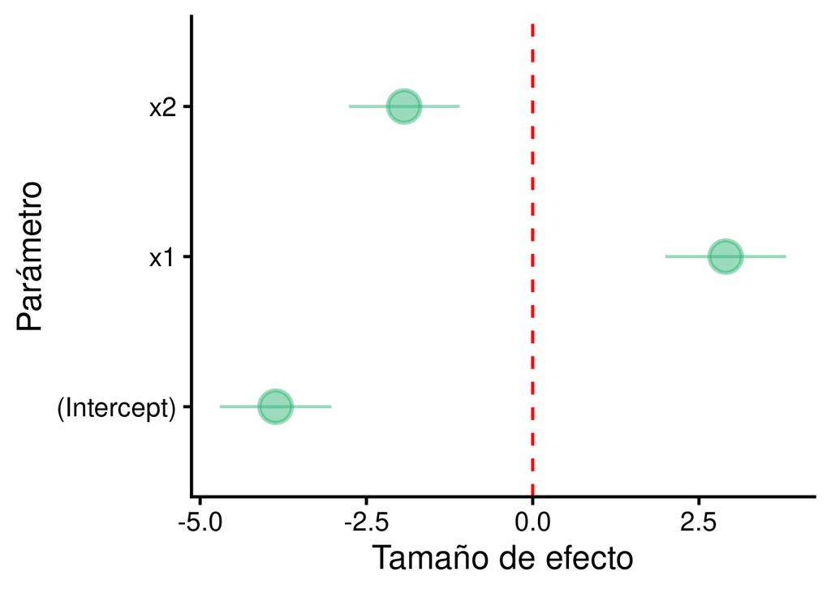

```r
ci_df <- data.frame(param = names(xy_mod_multp$coefficients),
                    est = xy_mod_multp$coefficients, confint(xy_mod_multp))

ggplot(ci_df, aes(x=param, y=est)) +
  geom_hline(yintercept = 0, color="red", lty = 2) +
  geom_pointrange(aes(ymin = X2.5.., ymax = X97.5..)) +
  labs(x = "Parámetro", y = "Tamaño de efecto") +
  coord_flip()
```

… y los gráficos diagnósticos:

**Código**

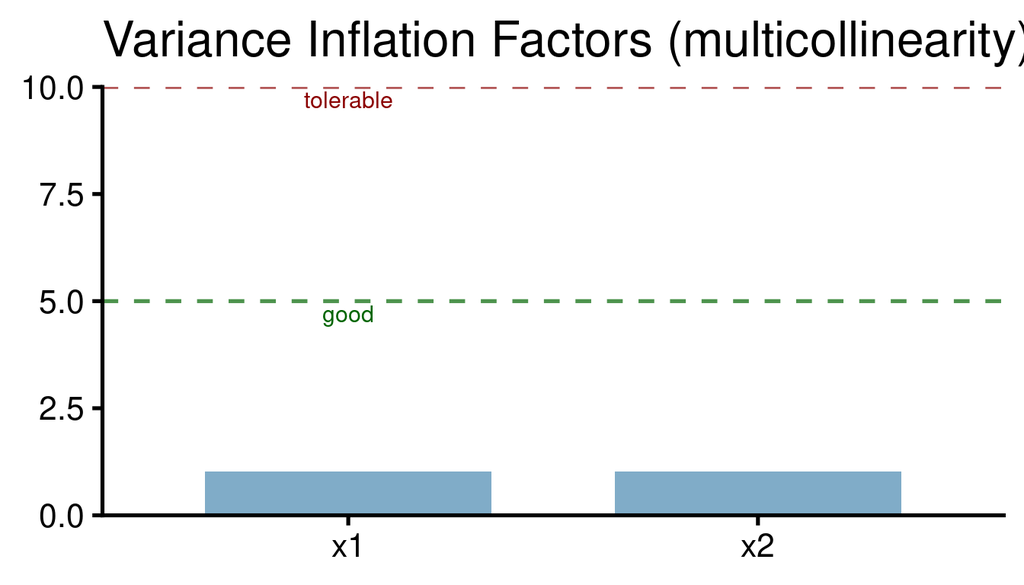

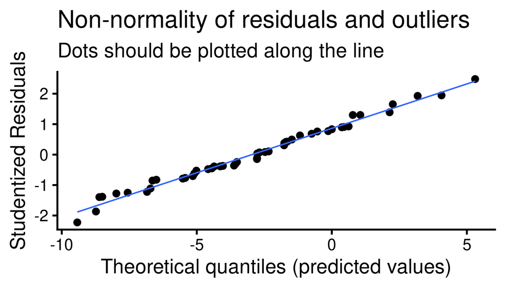

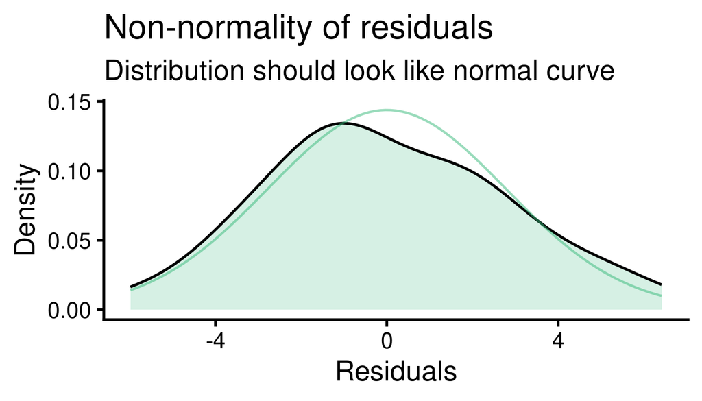

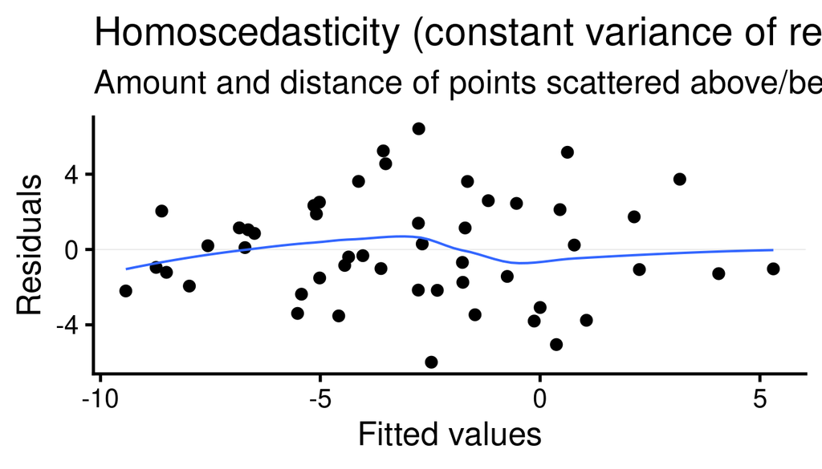

```r
plot_model(xy_mod_multp, type = "diag")
```

Hay un punto importante que es necesario enfatizar aquí: **la regresión múltiple estima el efecto de un predictor después de tener en cuenta el efecto de los demás predictores del modelo**. En otras palabras, los nuevos predictores del modelo tratarán de explicar la variación de los datos que no fue explicada por los otros predictores. Así que **el resultado de la regresión múltiple no es equivalente a los resultados de las regresiones lineales simples** sobre los predictores por separado. Esto puede demostrarse fácilmente corriendo esas regresiones:

**Código**

```r
coef(xy_mod_multp)# Resumen del modelo de multiple
```

```
(Intercept)          x1          x2
    -3.8652      2.9015     -1.9324
```

**Código**

```r
# Regresión simple de Y con A
mod_x1 <- lm(y ~ x1, data = xy_datos_multp)
coef(mod_x1)  # Resumen del modelo de regresión
```

```
(Intercept)          x1
    -3.4228      3.2310
```

**Código**

```r
# Regresión simple de Y con A
mod_x2 <- lm(y ~ x2, data = xy_datos_multp)
coef(mod_x2)  # Resumen del modelo de regresión
```

```
(Intercept)          x2
    -3.5456     -2.3468
```

Como vemos los tamaños de efecto para el mismo predictor difieren entre la regresión multiple y la simple. Esto se debe a que en **la regresion multiple ajusta los predictores para que se comporten como si fueran ortogonales entre sí**. Esto lo podemos simular sacando los residuos de cada predictor en una regresión contra todos los otros predictores en la regresión multiple. En nuestro caso es fácil ya que solo tenemos 2 predictores:

**Código**

```r
# Regresión de x1 sobre x2 para obtener los residuos
mod_resid_x1 <- lm(x1 ~ x2, data = xy_datos_multp)

# Obtener los residuos
xy_datos_multp$residuos_x1 <- resid(mod_resid_x1)

# Regresión de x2 sobre x1 para obtener los residuos
mod_resid_x2 <- lm(x2 ~ x1, data = xy_datos_multp)

# Obtener los residuos
xy_datos_multp$residuos_x2 <- resid(mod_resid_x2)
```

Ahora si corremos las regresiones simples con estos residuos, los tamaños de efecto coinciden con los obtenidos en la regresión multiple:

**Código**

```r
# Regresión de Y sobre los residuos de A
mod_resid_reg_x1 <- lm(y ~ residuos_x1, data = xy_datos_multp)

# Regresión de Y sobre los residuos de B
mod_resid_reg_x2 <- lm(y ~ residuos_x2, data = xy_datos_multp)

# Resúmenes finales de los modelos para comparar
coef(xy_mod_multp)[-1]
```

```
     x1      x2
 2.9015 -1.9324
```

**Código**

```r
c(coef(mod_resid_reg_x1)[-1], coef(mod_resid_reg_x2)[-1])
```

```
residuos_x1 residuos_x2
     2.9015     -1.9324
```

Por comodidad, hemos utilizado `coef()` para extraer sólo los estimado de la regresión, pero los valores son los mismos que obtenemos con `summary(model)`.

Este punto se demuestra además por el hecho de que, si uno de los predictores no tiene ninguna influencia en la respuesta, el efecto del predictor adicional convergerá a su efecto en una regresión lineal simple. Para simular este escenario, fijamos b2 en 0:

**Código**

```r
# definir semilla
set.seed(123)

# numero de observaciones
n <- 50
b0 <- -4
b1 <- 3
b2 <- 0
error <- rnorm(n = n, mean = 0, sd = 1)

#  variables aleatorias
x1 <-  rnorm(n = n, mean = 0, sd = 1)
x2 <-  rnorm(n = n, mean = 0, sd = 1)
y <- b0 + b1 * x1 + b2 * x2 + error

# crear data frame
xy_datos <- data.frame(x1, x2, y)

# construir modelos
xy_mod <- lm(formula = y ~ x1 + x2, data = xy_datos)
x1y_mod <- lm(formula = y ~ x1, data = xy_datos)

# shortcut to coefficients
coef(xy_mod)
```

```
(Intercept)          x1          x2
  -3.955064    2.967166    0.022549
```

**Código**

```r
coef(x1y_mod)
```

```
(Intercept)          x1
    -3.9602      2.9633
```

El estimado de $\beta_1$ fue casi el mismo en la regresión múltiple (2.96717) y en la regresión de un solo predictor (2.96332)

**Interpretación del modelo**

Cuadro con los coeficientes (estimados):

```
            Estimate Std. Error t value   Pr(>|t|)
(Intercept)  -3.8652    0.41695 -9.2702 3.4856e-12
x1            2.9015    0.45260  6.4108 6.4137e-08
x2           -1.9324    0.41422 -4.6650 2.5851e-05
```

**Caso de estudio**

- Araya-Salas M, P González-Gómez, K Wojczulanis-Jakubas, V López III & T Wright. 2018. [**Spatial memory is as important as weapon and body size for territorial ownership in a lekking hummingbird**](https://www.nature.com/articles/s41598-018-20441-x). *Scientific Reports*. 13, e0189969

“*La memoria espacial, el tamaño corporal y el largo de la punta del pico … predijeron positivamente la probabilidad de adquirir y defender un territorio.*”

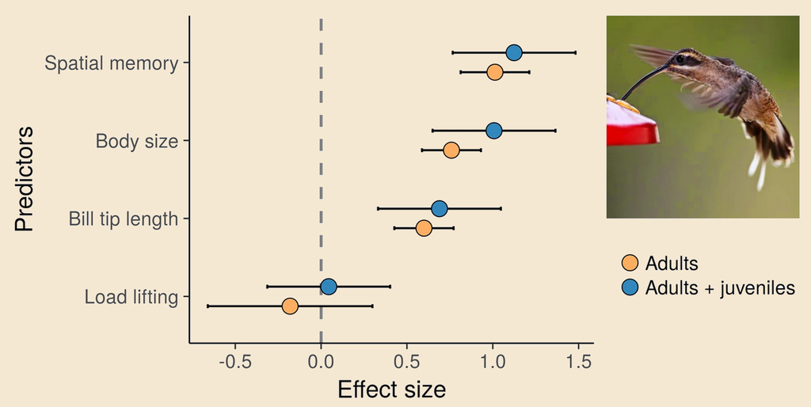

Ejercicio 5

La siguiente simulación genera un par de predictores continuos altamente colineales:

**Código**

```r
# definir semilla
set.seed(123)

# numero de observaciones
n <- 30
b0 <- -4
b1 <- 3
b2 <- -2
error <- rnorm(n = n, mean = 0, sd = 1)

#  variables aleatorias colineales
x1 <-  rnorm(n = n, mean = 0, sd = 1)
x2 <-  x1 + rnorm(n = n, mean = 0, sd = 0.2) # hacer x2 colineal con x1
y <- b0 + b1 * x1 + b2 * x2 + error

# crear data frame
xy_datos <- data.frame(x1, x2, y)

cor(x1, x2)
```

```
[1] 0.97812
```

**Código**

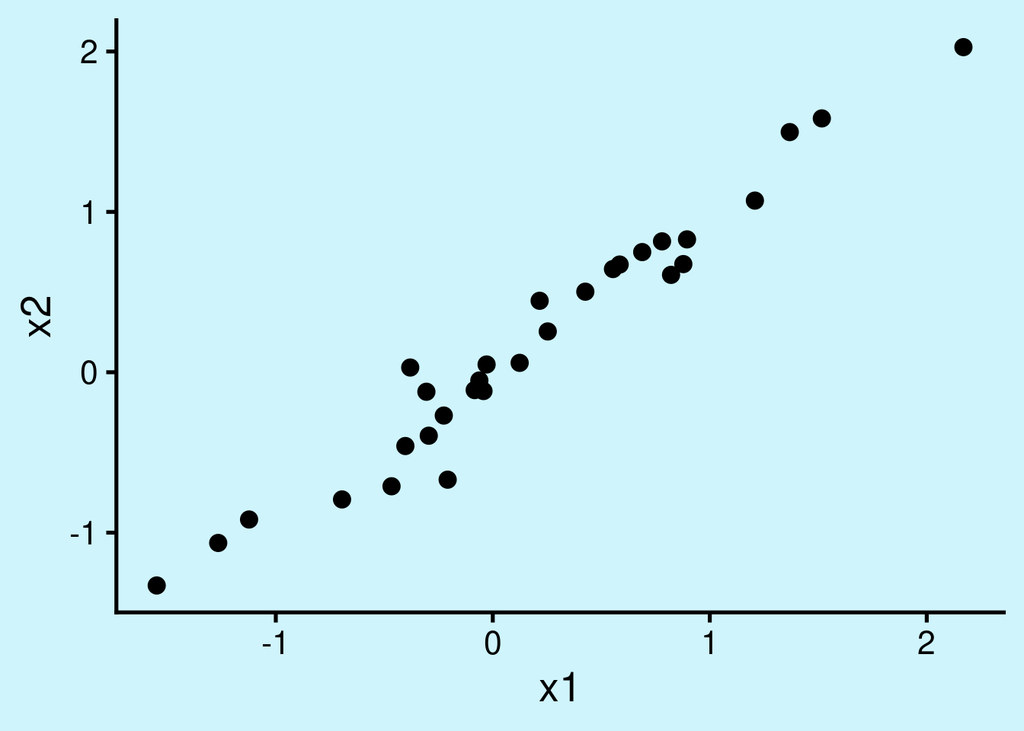

```r
# graficar
ggplot(data = xy_datos, aes(x = x1, y = x2)) +
    geom_point(size = 3)
```

- Construya un modelo lineal multiple (con `lm()`) con ‘y’ como respuesta y ‘x1’ y ‘x2’ como predictores
- Compare los betas estimados por el modelo con los usados para generar los datos. ¿Es una buena estimación?. También observe los valores de p. ¿Esperaría que fueran significativos?

## 1.5 Añadir un predictor categórico

Para los predictores categóricos podemos crear primero una variable binaria (0, 1) y luego añadir etiquetas a cada valor:

**Código**

```r
# definir semilla
set.seed(13)

# numero de observaciones
n <- 50
b0 <- -3
b1 <- 2
error <- rnorm(n = n, mean = 0, sd = 3)

#  variables aleatorias
x1_num <- sample(0:1, size = n, replace = TRUE)
y <- b0 + b1 * x1_num + error

x1 <- factor(x1_num, labels = c("a", "b"))

# crear data frame
xy_datos_cat <- data.frame(x1, x1_num, y)

head(xy_datos_cat)
```

| x1 | x1_num | y |
| --- | --- | --- |
| b | 1 | 0.66298 |
| a | 0 | -3.84082 |
| a | 0 | 2.32549 |
| b | 1 | -0.43804 |
| a | 0 | 0.42758 |
| a | 0 | -1.75342 |

Y así es como se escribe formalmente:

$\hat{Y} \sim \beta_{o} + \beta_{1} * x_{1}$

Lo mismo que con los predictores continuos.

Podemos explorar el patrón de los datos utilizando un diagrama de cajas (boxplot):

**Código**

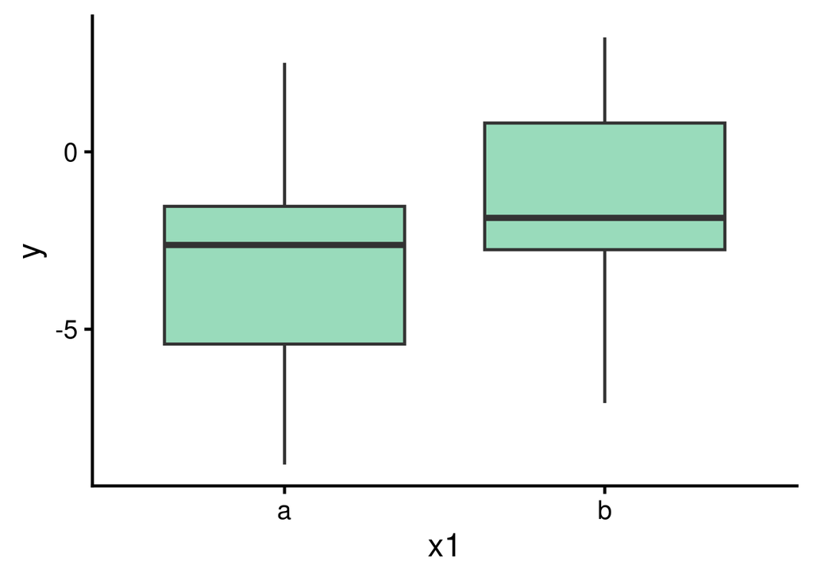

```r
# graficar
ggplot(xy_datos_cat, aes(x = x1, y = y)) +
  geom_boxplot()
```

… y obtener los estimados del modelo:

**Código**

```r
# construir modelos
xy_mod_cat <- lm(formula = y ~ x1, data = xy_datos_cat)

summary(xy_mod_cat)
```

```
Call:
lm(formula = y ~ x1, data = xy_datos_cat)

Residuals:
   Min     1Q Median     3Q    Max
-5.898 -1.909 -0.094  1.809  5.506

Coefficients:
            Estimate Std. Error t value Pr(>|t|)
(Intercept)   -2.997      0.558   -5.37  2.3e-06 ***
x1b            1.814      0.842    2.16    0.036 *
---
Signif. codes:  0 '***' 0.001 '**' 0.01 '*' 0.05 '.' 0.1 ' ' 1

Residual standard error: 2.95 on 48 degrees of freedom
Multiple R-squared:  0.0882,    Adjusted R-squared:  0.0693
F-statistic: 4.65 on 1 and 48 DF,  p-value: 0.0362
```

… graficar los tamaños de efecto:

**Código**

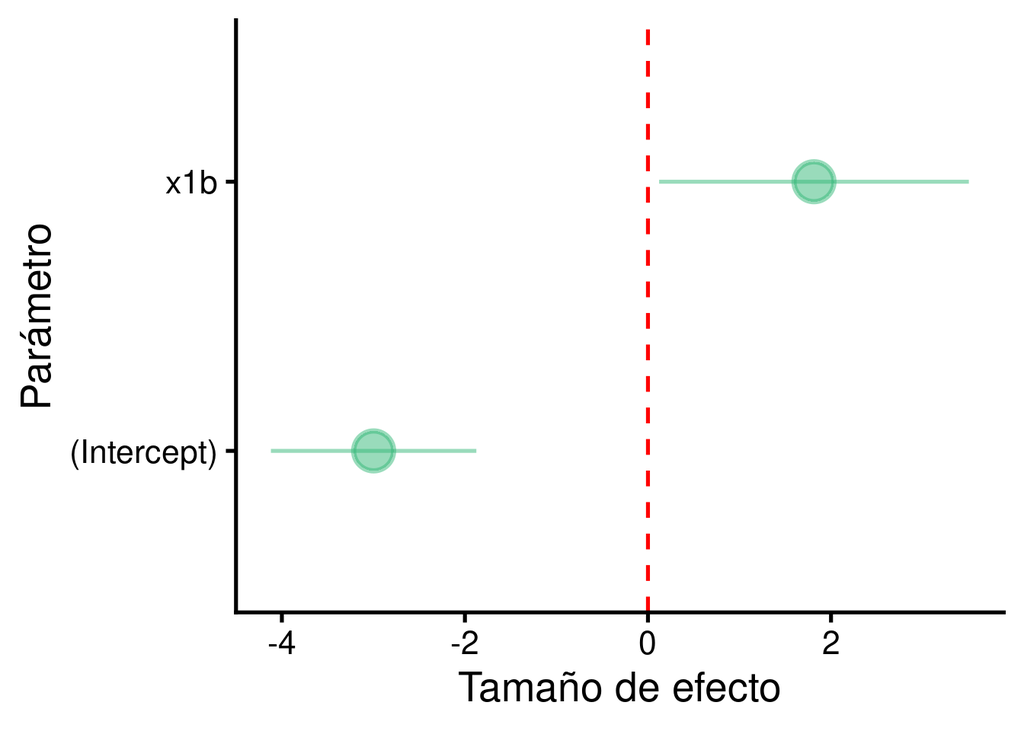

```r
ci_df <- data.frame(param = names(xy_mod_cat$coefficients),
                    est = xy_mod_cat$coefficients, confint(xy_mod_cat))

ggplot(ci_df, aes(x=param, y=est)) +
  geom_hline(yintercept = 0, color="red", lty = 2) +
  geom_pointrange(aes(ymin = X2.5.., ymax = X97.5..)) +
  labs(x = "Parámetro", y = "Tamaño de efecto") +
  coord_flip()
```

… y los gráficos diagnósticos del modelo:

**Código**

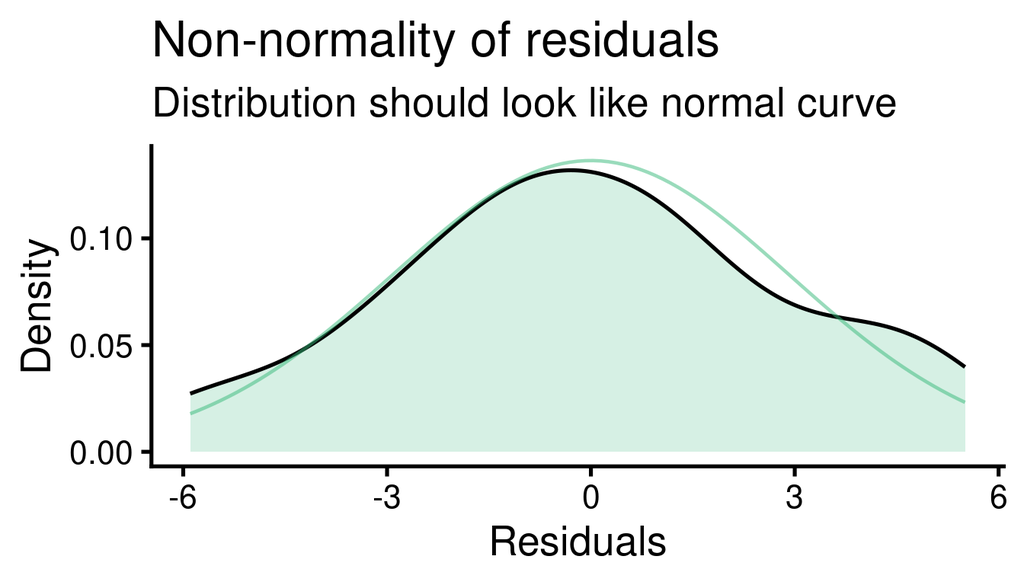

```r
plot_model(xy_mod_cat, type = "diag")[[2]]
```

**Interpretación del modelo**

Cuadro con los coeficientes (estimados):

```
            Estimate Std. Error t value   Pr(>|t|)
(Intercept)  -2.9974    0.55825 -5.3693 2.2677e-06
x1b           1.8140    0.84160  2.1554 3.6172e-02
```

- El modelo encontró que $\beta_1$ (el tamaño de efecto de ‘x1’) es 1.814 y que es significativamente diferente de 0 (p = 0.03617)
- Los valores simulados de los parámetros de regresión pueden compararse con el resumen del modelo `lm()` para tener una idea de la precisión del modelo:
  - $\beta_1$ se fijó en 2 y se estimó como 1.814.
- Tenga en cuenta que en este caso el intercepto se refiere a la estimación del nivel ‘a’ en el predictor categórico, que se utilizó como base:

**Código**

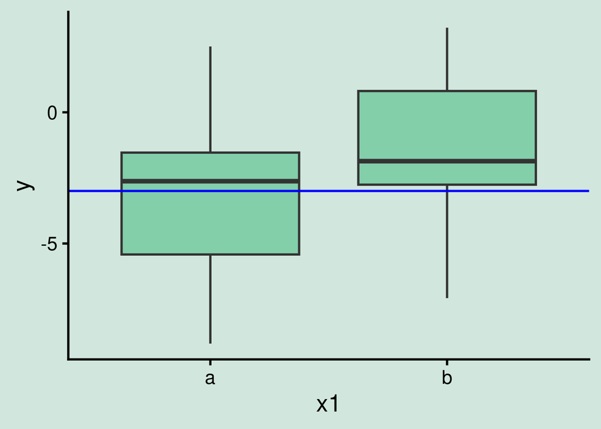

```r
# graficar
ggplot(xy_datos_cat, aes(x = x1, y = y)) +
  geom_boxplot() +
geom_hline(yintercept = xy_mod_cat$coefficients[1], col = "blue")
```

- Por lo tanto, el intercepto es el mismo que la media de *y* para la categoría ‘a’:

**Código**

```r
mean(xy_datos_cat$y[xy_datos_cat$x1 == "a"])
```

```
[1] -2.9974
```

- Observe también que la etiqueta del estimado es ‘x1b’, no ‘x1’ como en los predictores continuos. Esto se debe a que en este caso el estimado se refiere a la diferencia entre los dos niveles de la variable categórica (‘a’ y ‘b’). Más concretamente, nos dice que en promedio las observaciones de la categoría ‘b’ son 1.814 más altas que las observaciones de la categoría ‘a’.

**Caso de estudio**

- Rico-Guevara A, & M Araya-Salas. 2015. [**Bills as daggers? A test for sexually dimorphic weapons in a lekking hummingbird species**](https://academic.oup.com/beheco/article/26/1/21/2262689). *Behavioral Ecology*. 26 (1): 21-29.

“*Los machos con puntas de pico más grandes y puntiagudas tuvieron más éxito en ganar control de territorios en el lek.*”

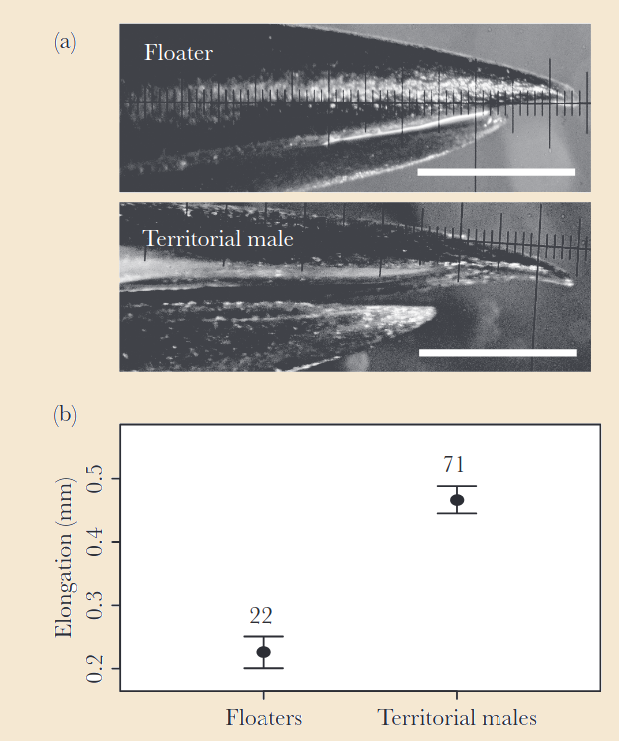

Ejercicio 6

- Los datos desbalanceados cuando hay categorías (es decir, algunas categorías tienen muchas más observaciones que otras) pueden ser problemáticos para la inferencia estadística. Modifique el código arriba para simular un juego de datos muy desbalanceado y compruebe la precisión del modelo.

Variables indicadoras (Dummy variables)

En un modelo de regresión, los predictores categóricos también se representan como vectores numéricos. Más concretamente, los predictores categóricos se codifican como 0s y 1s, en los que 1 significa “pertenece a la misma categoría” y 0 “pertenece a una categoría diferente”. Mantuvimos el vector numérico original (‘x1_num’) al simular el juego de datos con el predictor categórico:

**Código**

```r
head(xy_datos_cat)
```

| x1 | x1_num | y |
| --- | --- | --- |
| b | 1 | 0.66298 |
| a | 0 | -3.84082 |
| a | 0 | 2.32549 |
| b | 1 | -0.43804 |
| a | 0 | 0.42758 |
| a | 0 | -1.75342 |

Observe que las “b” de la columna “x1” se convierten en 1 en la columna “x1_num” y las “a” se convierten en 0. Esto se denomina variable indicadora y el proceso se conoce como ‘codificación indicadora’ (dummy coding).

En realidad, podemos utilizar el vector numérico en el modelo de regresión y obtener exactamente los mismos resultados:

**Código**

```r
# summary model with categorical variable
summary(xy_mod_cat)$coefficients
```

```
            Estimate Std. Error t value   Pr(>|t|)
(Intercept)  -2.9974    0.55825 -5.3693 2.2677e-06
x1b           1.8140    0.84160  2.1554 3.6172e-02
```

**Código**

```r
# construir modelos with dummy variable
xy_mod_num <- lm(formula = y ~ x1_num, data = xy_datos_cat)

# summary with dummy coding
summary(xy_mod_num)$coefficients
```

```
            Estimate Std. Error t value   Pr(>|t|)
(Intercept)  -2.9974    0.55825 -5.3693 2.2677e-06
x1_num        1.8140    0.84160  2.1554 3.6172e-02
```

Las cosas se complican un poco más cuando se codifica un predictor categórico con más de dos niveles. Pero la lógica es la misma.

## 1.6 Interacciones

Una interacción estadística se refiere a un efecto de una variable predictora que está mediado por una segunda variable.

$\hat{Y} \sim \beta_{o} + \beta_{1} * x_{1} + \beta_{2} * x_{2} + \beta_{3} * x_{1} * x_{2}$

Esto es más fácil de entender si se observa la interacción de una variable continua y una binaria:

**Código**

```r
# definir semilla
set.seed(123)

# numero de observaciones
n <- 50
b0 <- -4
b1 <- 3
b2 <- 1.7
b3 <- -3
error <- rnorm(n = n, mean = 0, sd = 3)

#  variables aleatorias
x1 <- rbinom(n = n, size = 1, prob = 0.5)
x2 <-  rnorm(n = n, mean = 0, sd = 1)

# interaccion se añade como el producto dex1 y x2
y <- b0 + b1 * x1 + b2 * x2 + b3 * x1 * x2 + error

x1 <- factor(x1, labels = c("a", "b"))

# crear data frame
xy_datos_intr <- data.frame(x1, x2, y)

head(xy_datos_intr)
```

| x1 | x2 | y |
| --- | --- | --- |
| b | 1.02557 | -4.0147 |
| a | -0.28477 | -5.1746 |
| a | -1.22072 | -1.3991 |
| b | 0.18130 | -1.0242 |
| a | -0.13889 | -3.8483 |
| b | 0.00576 | 4.1377 |

**Código**

```r
# construir modelos
xy_mod_intr <- lm(formula = y ~ x1 + x2 + x1 * x2, data = xy_datos_intr)

# guardar resumen para graficar lineas de mejor ajuste
xy_summ_intr <- summary(xy_mod_intr)

xy_summ_intr
```

```
Call:
lm(formula = y ~ x1 + x2 + x1 * x2, data = xy_datos_intr)

Residuals:
   Min     1Q Median     3Q    Max
-6.222 -1.664 -0.158  1.650  6.383

Coefficients:
            Estimate Std. Error t value Pr(>|t|)
(Intercept)   -4.193      0.570   -7.35  2.7e-09 ***
x1b            3.597      0.806    4.46  5.2e-05 ***
x2             1.327      0.682    1.95   0.0576 .
x1b:x2        -2.972      0.962   -3.09   0.0034 **
---
Signif. codes:  0 '***' 0.001 '**' 0.01 '*' 0.05 '.' 0.1 ' ' 1

Residual standard error: 2.83 on 46 degrees of freedom
Multiple R-squared:  0.396, Adjusted R-squared:  0.357
F-statistic:   10 on 3 and 46 DF,  p-value: 3.29e-05
```

También ayuda graficar los datos:

**Código**

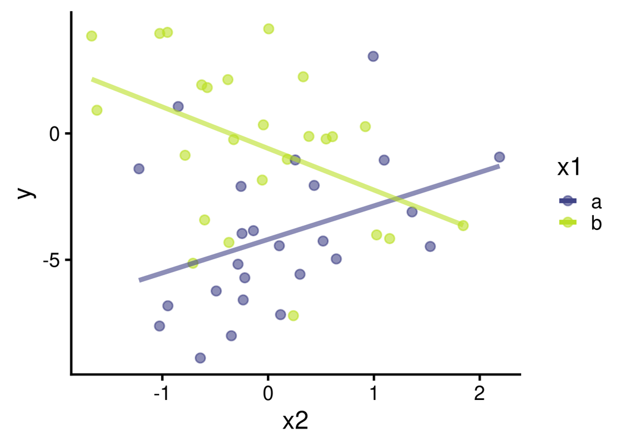

```r
# graficar
ggplot(data = xy_datos_intr, aes(x = x2, y = y, color = x1)) +
    geom_point(size = 3) +
    geom_smooth(method = "lm", se = FALSE)
```

… y los tamaños de efecto:

**Código**

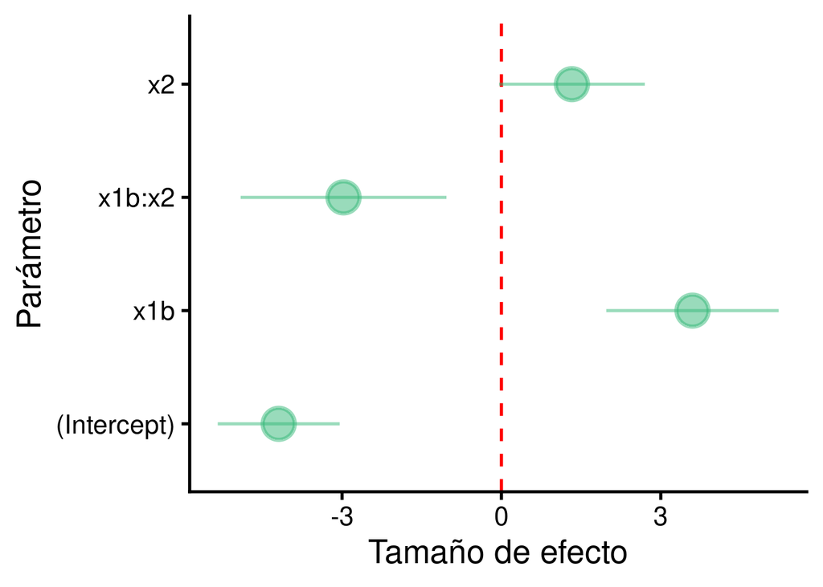

```r
ci_df <- data.frame(param = names(xy_mod_intr$coefficients),
                    est = xy_mod_intr$coefficients, confint(xy_mod_intr))

ggplot(ci_df, aes(x=param, y=est)) +
  geom_hline(yintercept = 0, color="red", lty = 2) +
  geom_pointrange(aes(ymin = X2.5.., ymax = X97.5..)) +
  labs(x = "Parámetro", y = "Tamaño de efecto") +
  coord_flip()
```

También deberíamos revisar los gráficos de diagnóstico:

**Código**